# Розділ 4 Лабораторна робота №3. Розвідувальний аналіз даних. Візуалізація

2023-01-31

[Daniil Tereshchenko](https://www.linkedin.com/in/daniil-tereshchenko/), 2023

### Варіація

**Варіація (Variation)** – це тенденція до змін значення змінної від вимірювання до вимірювання. Ми можете легко помітити варіації в реальному житті; якщо ми двічі вимірюємо постійну змінну, ми отримаємо два різні результати.  
Категоричні змінні також можуть відрізнятися, якщо виміри робити для різних суб’єктів (наприклад, кольори очей різних людей) або у різні моменти часу (наприклад, енергетичні рівні електрона в різні моменти). Кожна змінна має свій власний паттерн у варіації, який може виявити цікаву інформацію. Найкращий спосіб зрозуміти цю закономірність – візуалізувати розподіл значень змінної.

#### Візуалізація розподілу

Нижче наведено приклад розподілу категоріальної змінної.

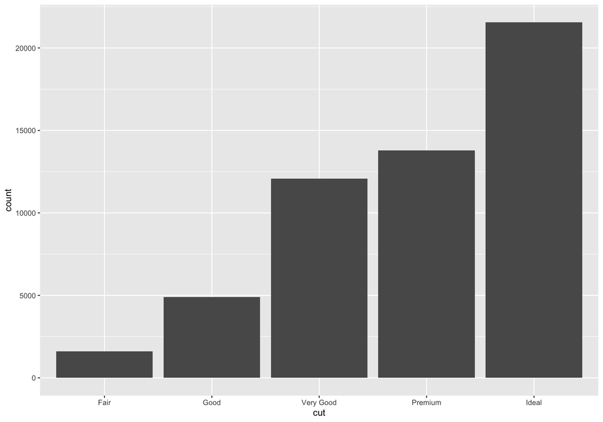

```r
library(tidyverse)
library(ggplot2)
ggplot(data = diamonds) +
  geom_bar(mapping = aes(x = cut))
```

Частоту для кожного значення категоріальної змінної можна обчислита, наприклад, так:

```r
diamonds %>%
  count(cut)
```

```
## # A tibble: 5 × 2
##   cut           n
##   <ord>     <int>
## 1 Fair       1610
## 2 Good       4906
## 3 Very Good 12082
## 4 Premium   13791
## 5 Ideal     21551
```

Для неперервної змінної доцільно побудувати гістограму:

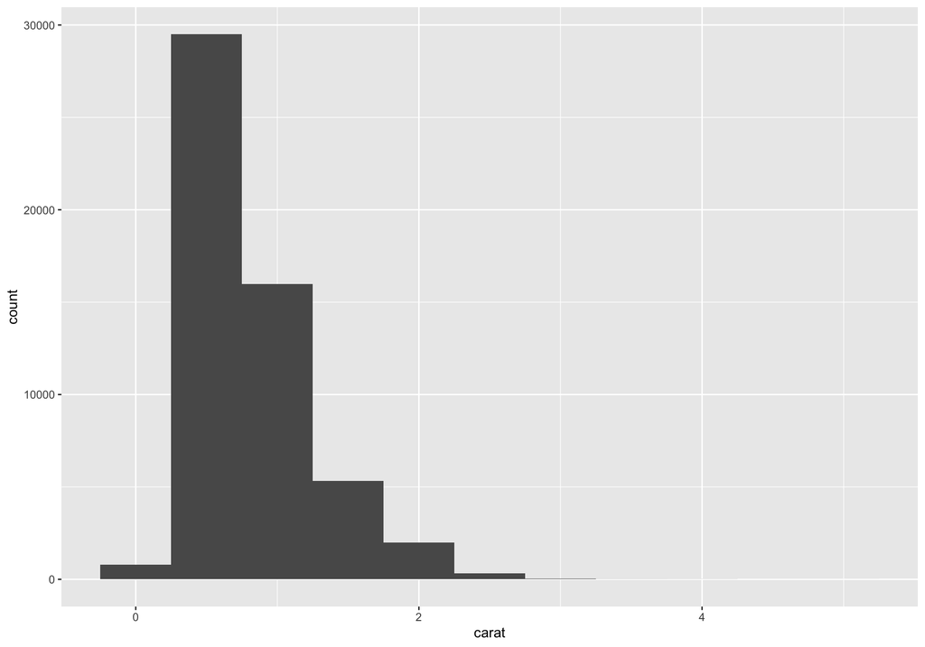

```r
ggplot(data = diamonds) +
  geom_histogram(mapping = aes(x = carat), binwidth = 0.5)
```

Інтервальна таблиця частот, що відповідає гістограмі, може бути обчислена так:

```r
diamonds %>%
  count(cut_width(carat, 0.5))
```

```
## # A tibble: 11 × 2
##    `cut_width(carat, 0.5)`     n
##    <fct>                   <int>
##  1 [-0.25,0.25]              785
##  2 (0.25,0.75]             29498
##  3 (0.75,1.25]             15977
##  4 (1.25,1.75]              5313
##  5 (1.75,2.25]              2002
##  6 (2.25,2.75]               322
##  7 (2.75,3.25]                32
##  8 (3.25,3.75]                 5
##  9 (3.75,4.25]                 4
## 10 (4.25,4.75]                 1
## 11 (4.75,5.25]                 1
```

Можна побудувати гістограму для певної долі значень:

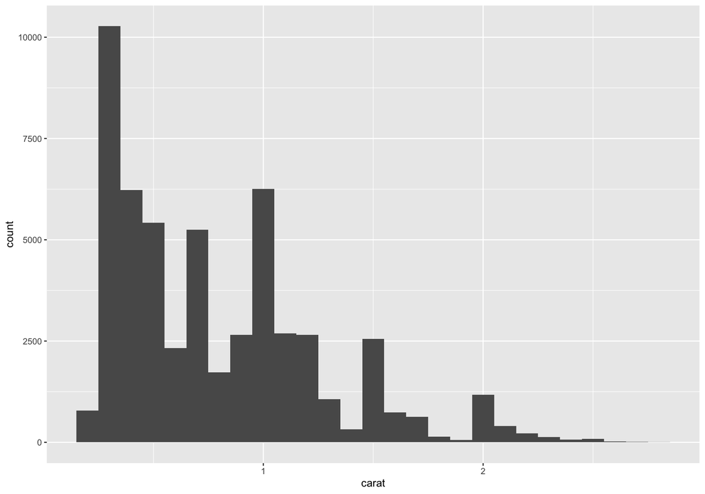

```r
smaller <- diamonds %>%
  filter(carat < 3)

ggplot(data = smaller, mapping = aes(x = carat)) +
  geom_histogram(binwidth = 0.1)
```

Часто буває доцільно побудувати серію гістограм для різних груп спостережень:

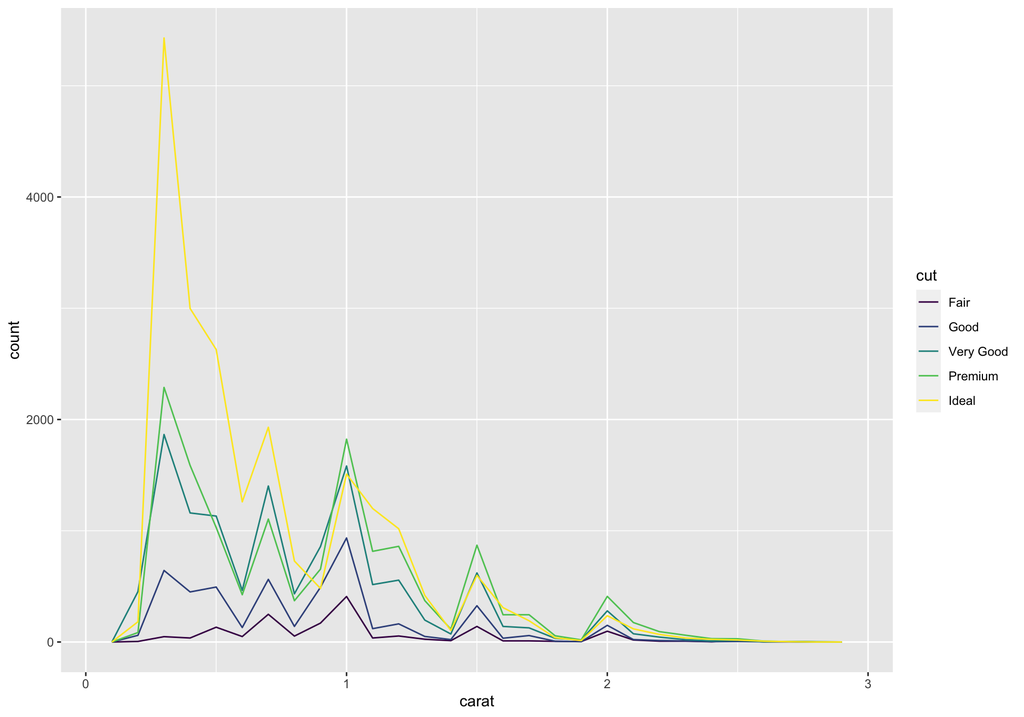

```r
ggplot(data = smaller, mapping = aes(x = carat, colour = cut)) +
  geom_freqpoly(binwidth = 0.1)
```

Після того, як ми виконали візуалізацію, що ми маємо знайти на цих графіках? Яка може бути послідовність запитань на наступному етапі?

*Типові запитання з урахуванням специфіка даної задачі можуть виглядати так:

- Які значення є найбільш поширеними? Чому?
- Які значення є рідкісними? Чому? Це відповідає нашим очікуванням?
- Чи бачемо ми якісь незвичайні закономірності? Що може їх пояснити?

Як приклад, гістограма нижче наводить кілька цікавих питань:

- Чому там більше діамантів праворуч від кожного піка, ніж трохи ліворуч від кожного піка?
- Чому немає діамантів більше 3 каратів?

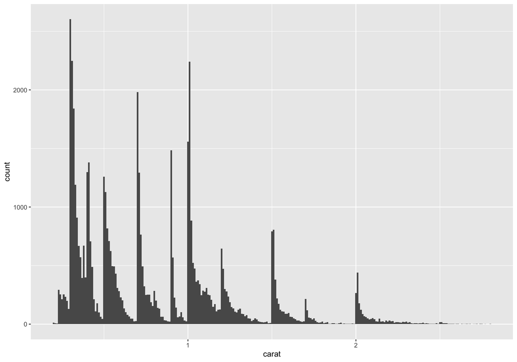

```r
ggplot(data = smaller, mapping = aes(x = carat)) +
         geom_histogram(binwidth = 0.01)
```

#### Незвичайні значення

Як правило у вибіркових даних зустірчаються викиди (outliers) – такі значення свідчать або про похибку вимірювання, або про якість надзвичайні причини, що потребують уважного вивчення.

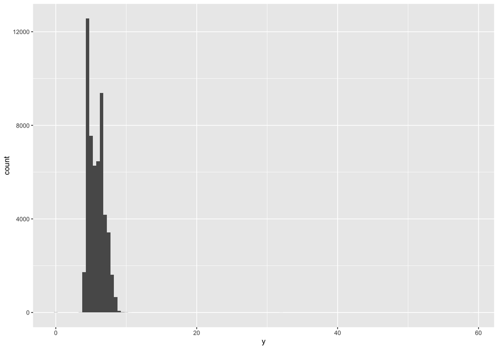

```r
ggplot(diamonds) +
  geom_histogram(mapping = aes(x = y), binwidth = 0.5)
```

Для того, щоб їх побачити, необхідно певним чином масштабувати гістограму:

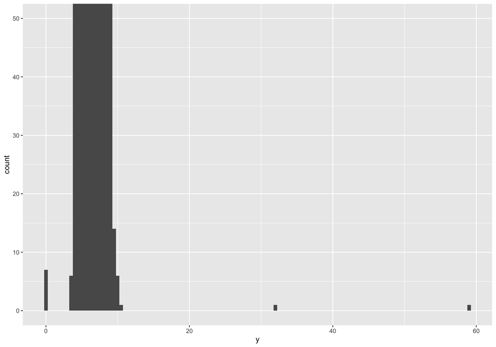

```r
ggplot(diamonds) +
  geom_histogram(mapping = aes(x = y), binwidth = 0.5) +
  coord_cartesian(ylim = c(0, 50))
```

Якщо приймається рішення їх видалити, то це можна зроити наступним чином:

```r
unusual <- diamonds %>%
  filter(y < 3 | y > 20) %>%
  select(price, x,y,z) %>%
  arrange(y)
unusual
```

```
## # A tibble: 9 × 4
##   price     x     y     z
##   <int> <dbl> <dbl> <dbl>
## 1  5139  0      0    0
## 2  6381  0      0    0
## 3 12800  0      0    0
## 4 15686  0      0    0
## 5 18034  0      0    0
## 6  2130  0      0    0
## 7  2130  0      0    0
## 8  2075  5.15  31.8  5.12
## 9 12210  8.09  58.9  8.06
```

#### Пропущені значення (Missing values)

Часто на практиці дані виявляються некомплектними – мають місце пропущенні дані (`NA`). У таких випадках відомі два виходи з систуації:

- видалити некомплектні спостереження
- виконати імпутацію пропущених значень – замінити пропущені значення певними у відповідності з якимось алгоритмом.

Пакет `ggplot2` автоматично видаляє некмоплектні дані:

```r
diamonds
```

```
## # A tibble: 53,940 × 10
##    carat cut       color clarity depth table price     x     y     z
##    <dbl> <ord>     <ord> <ord>   <dbl> <dbl> <int> <dbl> <dbl> <dbl>
##  1  0.23 Ideal     E     SI2      61.5    55   326  3.95  3.98  2.43
##  2  0.21 Premium   E     SI1      59.8    61   326  3.89  3.84  2.31
##  3  0.23 Good      E     VS1      56.9    65   327  4.05  4.07  2.31
##  4  0.29 Premium   I     VS2      62.4    58   334  4.2   4.23  2.63
##  5  0.31 Good      J     SI2      63.3    58   335  4.34  4.35  2.75
##  6  0.24 Very Good J     VVS2     62.8    57   336  3.94  3.96  2.48
##  7  0.24 Very Good I     VVS1     62.3    57   336  3.95  3.98  2.47
##  8  0.26 Very Good H     SI1      61.9    55   337  4.07  4.11  2.53
##  9  0.22 Fair      E     VS2      65.1    61   337  3.87  3.78  2.49
## 10  0.23 Very Good H     VS1      59.4    61   338  4     4.05  2.39
## # … with 53,930 more rows
```

```r
diamonds2 <- diamonds %>%
  mutate(y = ifelse( y < 3 | y > 20, NA, y))
```

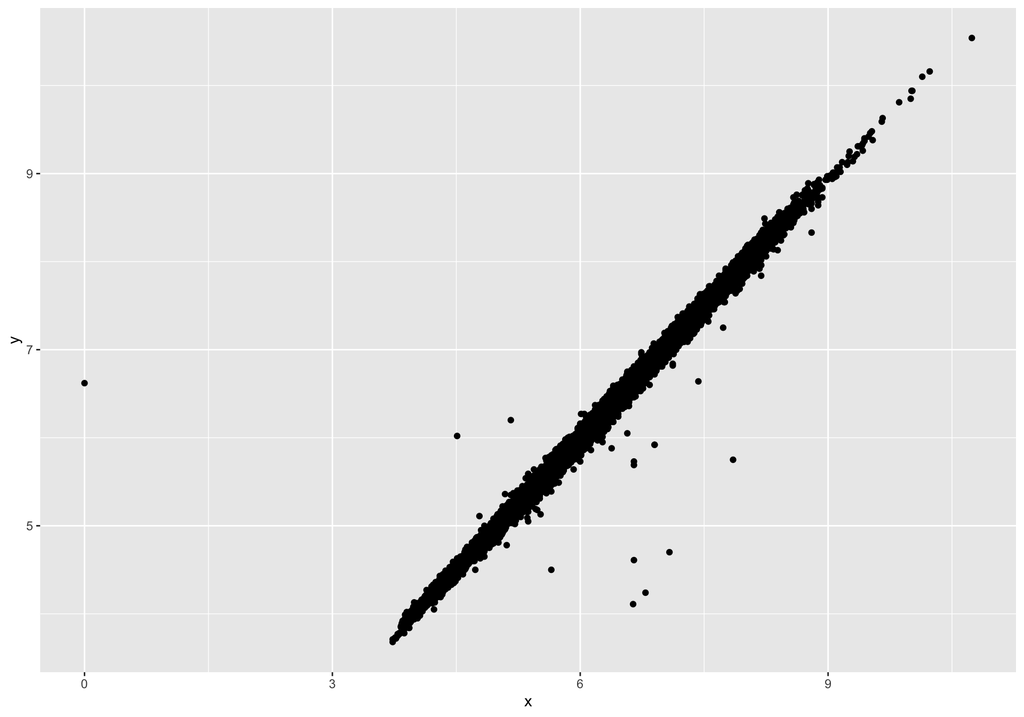

```r
ggplot(data = diamonds2, mapping = aes(x = x, y = y)) +
  geom_point()
```

Інколи ми хочемо зрозуміти, що робить спостереження з відсутніми значеннями, відмінними від спостережень із записаними значеннями. Наприклад, у `nycflights13::flights`, відсутні значення в змінній `dep_time` (час вильоту) показують, що рейс був скасований. Тому, можливо, нам потрібно буде порівняти заплановані терміни вильоту для скасованих та не скасованих часів. Ми можемо зробити це, зробивши нову змінну з `is.na()`:

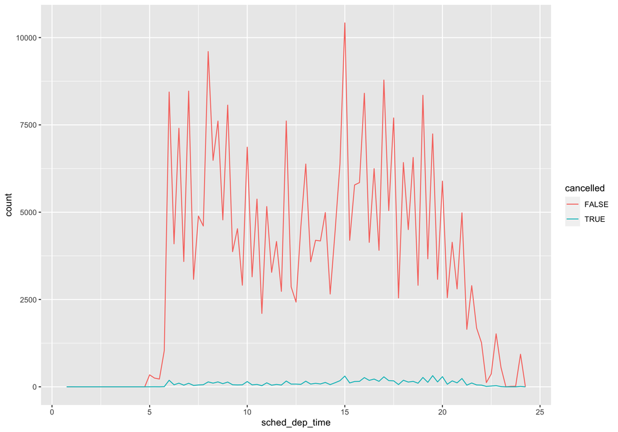

```r
nycflights13::flights %>%
  mutate(
    cancelled = is.na(dep_time),
    sched_hour = sched_dep_time %/% 100,
    sched_min = sched_dep_time %% 100,
    sched_dep_time = sched_hour + sched_min / 60
  ) %>%
  ggplot(mapping = aes(sched_dep_time)) +
    geom_freqpoly(mapping = aes(colour = cancelled), binwidth = 1/4)
```

### Коваріація

Якщо варіація описує поведінку в межах змінної, коваріація описує поведінку між змінними.  
**Коваріація (Covariation)** – це схильність значень двох чи більше змінних змінюватися разом. Найкращим способом виявлення коваріації є візуалізація відносин між двома чи більше змінних.

#### Категоріальні та неперервні змінні

Природнім є рішення щодо вивчення розподілу неперервної змінної, розбивши її на групи у відповідності до значень категоріальної змінної, як у попередньому багатокутнику частот. Поява за замовчуванням `geom_freqpoly()` не є таким корисним для подібного порівняння, оскільки його висоту визначає кількість. Це означає, що якщо одна з груп є набагато меншою, ніж інші, важко побачити відмінності у формі. Наприклад, давайте розглянемо, як ціна діамантів змінюється залежно від його якості:

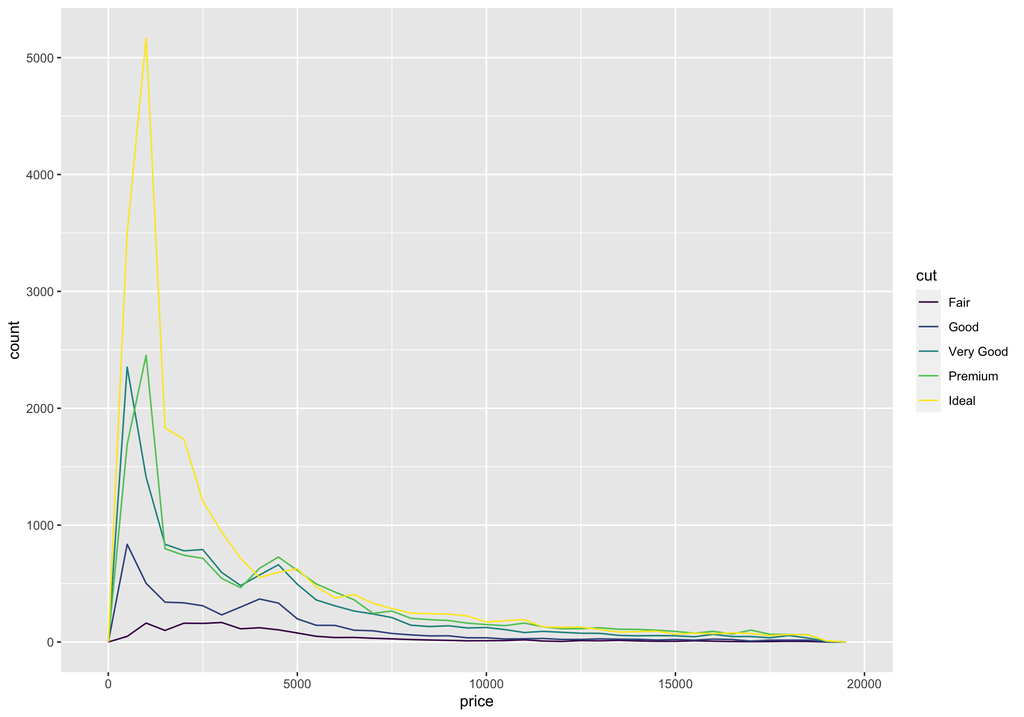

```r
ggplot(data = diamonds, mapping = aes(x = price)) +
  geom_freqpoly(mapping = aes(colour = cut), binwidth = 500)
```

Важко побачити різницю в розподілах, оскільки кількість вибіркових значень у кожній групі суттєво відрізняється:

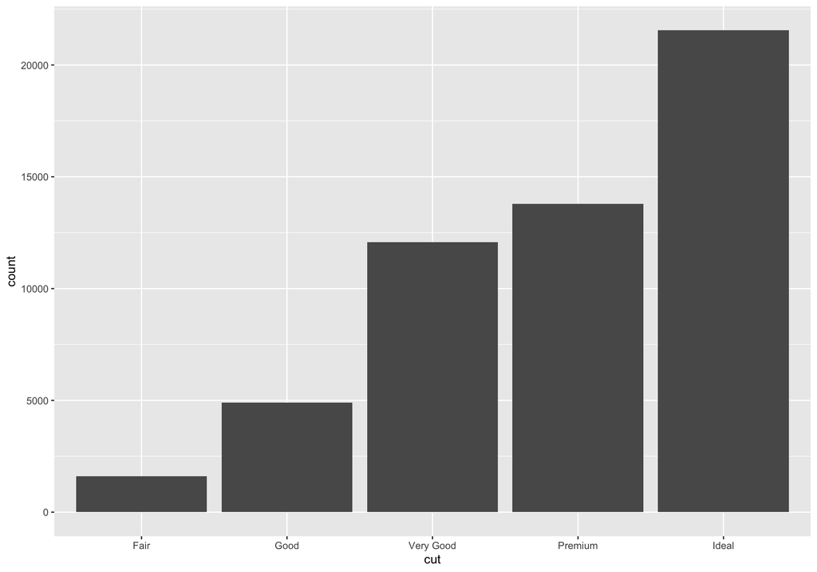

```r
ggplot(diamonds) +
  geom_bar(mapping = aes(x = cut))
```

Для полегшення порівняння нам потрібно поміняти те, що відображається на осі Y. Замість того, щоб відображати частоту, ми покажемо відносну частоту, яка є нормованою величиною.

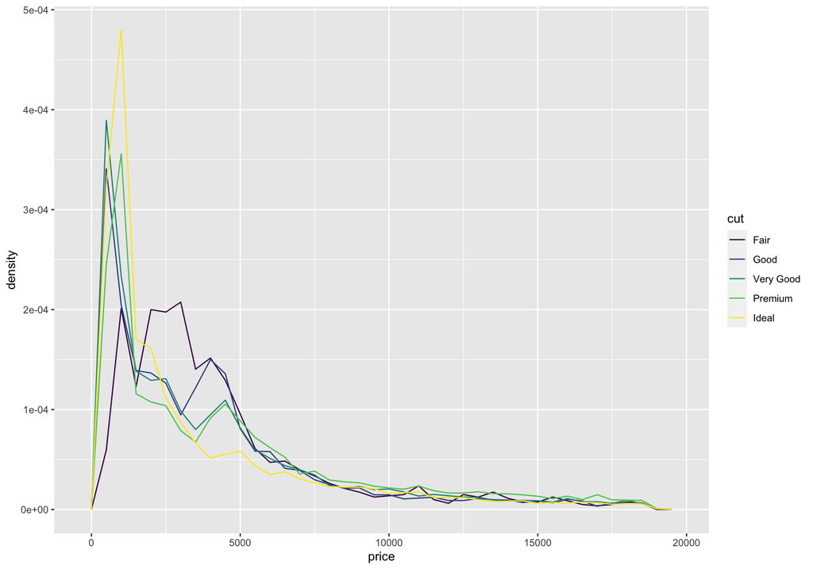

```r
ggplot(data = diamonds, mapping = aes(x = price, y = ..density..)) +
  geom_freqpoly(mapping = aes(colour = cut), binwidth = 500)
```

В результаті можна побачити, що найвищу середню ціну мають посередні діаманти (fair). Але аналіз щільностей розпоілів є не зовсім зручним. Альтернативним варіантом представлення аналогічної інформації є п’ятиквантильний графік (boxplot, box and wiskers plot), відомий як “боксплот,” або “ящик з вусами.” Боксплот акумулює в собі всі найважливіші інтегральні харакетристики стосовно мір центральної тенденції, розсіювання та форми розподілу.Тоді для нашого випадку застосування боксплотів дасть такий результат:

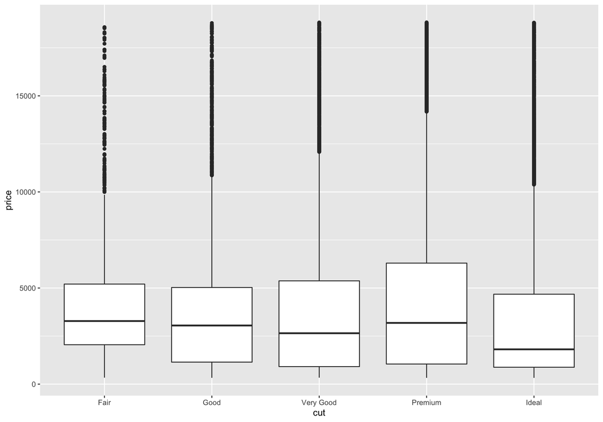

```r
ggplot(data = diamonds, mapping = aes(x = cut, y = price)) +
  geom_boxplot()
```

#### Дві категоріальні змінні

Для візуалізації коваріації між категоріальними змінними неохідно візуалізувати частоти: у вигляді таблиці, або певного графічного візуалізатора. Наприклад:

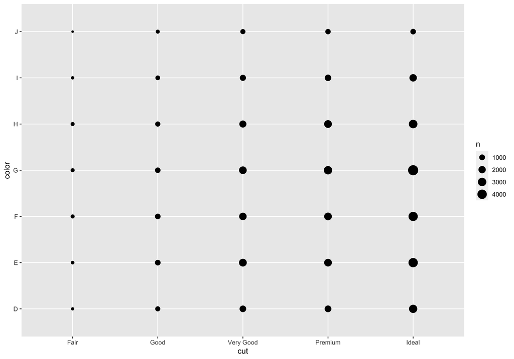

```r
ggplot(data = diamonds) +
  geom_count(mapping = aes(x = cut, y = color) )
```

З результатів видно, що існує певна залежність між кольором діаманта, та якістю його ограненості.

#### Пакет `FunModelling`

- `df_status()` : структура набору даних для профілювання
- `describe()` : чисельне та категоріальне профілювання (кількісне)
- `freq()`: категоріальне профілювання (кількісне та графік).
- `profileing_num()`: профілювання для числових змінних (кількісний)
- `plot_num (дані)` : профілювання для числових змінних (графіки)

### Зниження розмірності даних

**[Зниження розмірності (Dimensionality reduction)](https://en.wikipedia.org/wiki/Dimensionality_reduction)** – процесс скорочення кількості випадкових змінних шляхом отримання гооловних змінних. Цей процес можно поділити *обирання ознак* та *виділяння ознак*.  
*Обирання ознак* – це процес пошуку первісних змінних (факторів), що починаються в рамках фази розуміння даних із залученням експертів предметної галузі і з залученням всього арсеналу інстурментів маніпулювання даними, про що йшлося вище. (Маніпулятивні методики).  
*Проектування ознак* – це перетворення даних з багатовимірного простору у простір простір невеликої кількості вимірів. (Математичні методики). (Далі під зниженням розмірнонсті будем мати на увазі саме проектування ознак). Існує велика кількість лінійних і нелінійних методик зниження розмірності.  
Що дає зниження розмірності на практиці? В першу чергу спрощення представлення багатовимірних даних, їх візуалізацію, вирішення задач класифікації та регресії і, власне, краще розуміння процесів, що моделюються.  
Одним з фундаментальних лінійних методів зниження розмірності, що широко викорстовується на практиці, є [PCA](https://en.wikipedia.org/wiki/Principal_component_analysis) (wikipedia 2018).

#### Постановка задачі аналізу методом главних компонент (PCA)

Припустимо (wikipedia 2018), що ми маємо випадковий вектор *X*:

$$X=\begin{pmatrix}
x_1 \\
x_2 \\
\vdots \\
x_n
\end{pmatrix}$$
З коваріаційною матрицею:

$$var(X) = \Sigma =
\begin{pmatrix}
\sigma_{1}^2 & \sigma_{12} & \ldots & \sigma_{1p}\\
\sigma_{21} & \sigma_{2}^2 & \ldots & \sigma_{2p}\\
\vdots & \vdots & \ddots & \vdots\\
\sigma_{p1} & \sigma_{p2} & \ldots & \sigma_{p}^2
\end{pmatrix}$$

*Y*<sub>1</sub> = *a*<sub>11</sub>*X*<sub>1</sub> + *a*<sub>12</sub>*X*<sub>2</sub> + ⋯ + *a*<sub>1*p*</sub>*X*<sub>*p*</sub>

*Y*<sub>2</sub> = *a*<sub>21</sub>*X*<sub>1</sub> + *a*<sub>22</sub>*X*<sub>2</sub> + ⋯ + *a*<sub>2*p*</sub>*X*<sub>*p*</sub>

$⋮$

*Y*<sub>*k*</sub> = *a*<sub>*k*1</sub>*X*<sub>1</sub> + *a*<sub>*k*2</sub>*X*<sub>2</sub> + ⋯ + *a*<sub>*k**p*</sub>*X*<sub>*p*</sub>

При цьому $\sum\limits_{i=1}^pa_{1i}^2=1$ і т. д.

Дисперсия першої главної компоненти *v**a**r*(*Y*<sub>1</sub>) = *a*<sub>1</sub>′*Σ**a*<sub>1</sub>, де *Σ* – ковариаційна матриця.

Аналогічно обчислюється дисперсія другої і т. д. головних компонент.

У даній моделі вектори $a_i'=(a_{i1}, a_{i2},...,a_{ip})',\;i=\overline{1,p}$ представляють *власні вектори* ковариаційної матриці *Σ*, тоді як дисперсія *i*-ої головної компоненти дорівнює *власному значенню* матриці ковариацій:

*v**a**r*(*Y*<sub>*i*</sub>) = *λ*<sub>*i*</sub>.

*Загальна дисперсія* вибірки дорівнює $\sum\limits_{i=1}^p\lambda_{i}.$  
Метод головних компонент (PCA) вирішуючи задачу зниження розмірності дозволяє одночасно вирішити задачу сегементації (кластеризації) – тобто з’ясувати, чи є досліджувані дані однорідними, чи сегментовані на групи зі схожими ознаками. Відповідь на це питання є однією з головних задач експлораторного аналізу, що передує етапу побуви більш складних моделей класифікації, регресії чи моделей на основі асоціативних правил.

В арсеналі R існує багато інструментів для реалізації зниження розмірності, зокрема PCA.

# Виконання індивідуального завдання

Дані з досліджуваного набору мають наступний вигляд:

```r
iris %>%
  head()
```

```
##   Sepal.Length Sepal.Width Petal.Length Petal.Width Species
## 1          5.1         3.5          1.4         0.2  setosa
## 2          4.9         3.0          1.4         0.2  setosa
## 3          4.7         3.2          1.3         0.2  setosa
## 4          4.6         3.1          1.5         0.2  setosa
## 5          5.0         3.6          1.4         0.2  setosa
## 6          5.4         3.9          1.7         0.4  setosa
```

Обчислимо і дослідимо сумарні статистики.

```r
iris %>%
  df_status()
```

```
##       variable q_zeros p_zeros q_na p_na q_inf p_inf    type unique
## 1 Sepal.Length       0       0    0    0     0     0 numeric     35
## 2  Sepal.Width       0       0    0    0     0     0 numeric     23
## 3 Petal.Length       0       0    0    0     0     0 numeric     43
## 4  Petal.Width       0       0    0    0     0     0 numeric     22
## 5      Species       0       0    0    0     0     0  factor      3
```

Що ми бачимо?

Дослідимо закони розподілу кожної з чотирьох змінних.

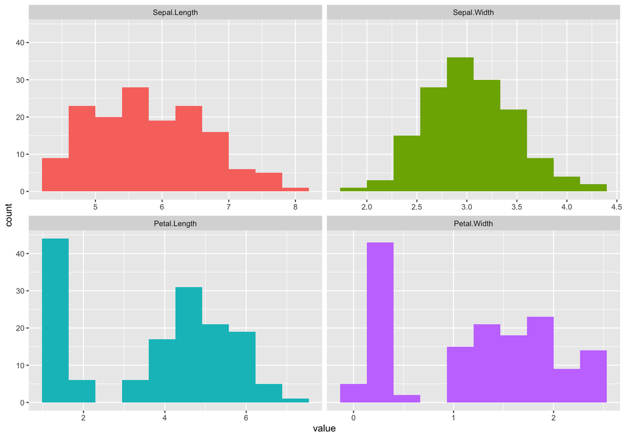

```r
iris %>%
  plot_num()
```

```r
iris %>%
  profiling_num()
```

```
##       variable     mean   std_dev variation_coef  p_01  p_05 p_25 p_50 p_75
## 1 Sepal.Length 5.843333 0.8280661      0.1417113 4.400 4.600  5.1 5.80  6.4
## 2  Sepal.Width 3.057333 0.4358663      0.1425642 2.200 2.345  2.8 3.00  3.3
## 3 Petal.Length 3.758000 1.7652982      0.4697441 1.149 1.300  1.6 4.35  5.1
## 4  Petal.Width 1.199333 0.7622377      0.6355511 0.100 0.200  0.3 1.30  1.8
##    p_95  p_99   skewness kurtosis iqr     range_98    range_80
## 1 7.255 7.700  0.3117531 2.426432 1.3   [4.4, 7.7]  [4.8, 6.9]
## 2 3.800 4.151  0.3157671 3.180976 0.5 [2.2, 4.151] [2.5, 3.61]
## 3 6.100 6.700 -0.2721277 1.604464 3.5 [1.149, 6.7]  [1.4, 5.8]
## 4 2.300 2.500 -0.1019342 1.663933 1.5   [0.1, 2.5]  [0.2, 2.2]
```

Що ми бачимо?

- статистичні розподіли змінних `"Sepal.Length"`, `"Sepal.Width"` мають дзвоноподібну форму, наближену до нормального. Враховуючи, що значення оцінок асимметрії та ексцесу несуттєво відрізняються від нуля, в першому наближенні можна вважати дані розподіли нормальними. Про що це говорить і що це дає? По-перше, це говорить про те, що доля малих і великих даних врівноважують одна одну, по-друге, нормальність законів розподілу досліджуваних величин, або, принаймні, “натяк” на нормальність **завжди добре**, тому що класичними передумовами для коректної побудови великої кількості різного роду моделей вимагає від даних нормального закону розподілу, чи, принаймні, симетричності закону розподілу. В нашому випадку це є передумовою однорідного розподілу спостережень у просторі інформативних ознак, що є позитивним моментом при вирішенні задачі сегментації.
- статистичні розподіли змінних `"Petal.Length"`, `"Petal.Width"` на відміну від двох інших, мають чітку бімодальну структуру, що гооврить про явно виражену неоднорідність даних і про те, що саме ці дві змінні є дискримінуючими у просторі досліджуваних ознак; це важливо для побудови задачі сегментації

Для відповіді на питання, чи пов’язані між собою змінні, застосуємо кореляційний аналіз. З урахуванням числової природи даних, для оцінки кореляції скористаємося коефіцієнтом кореляції Пірсона. Враховуючі багатомірний аналіз початкових даних, важливо вдало підібрати візуалізатор. Нижче запропоновано два з найбільш відомих і поширених.

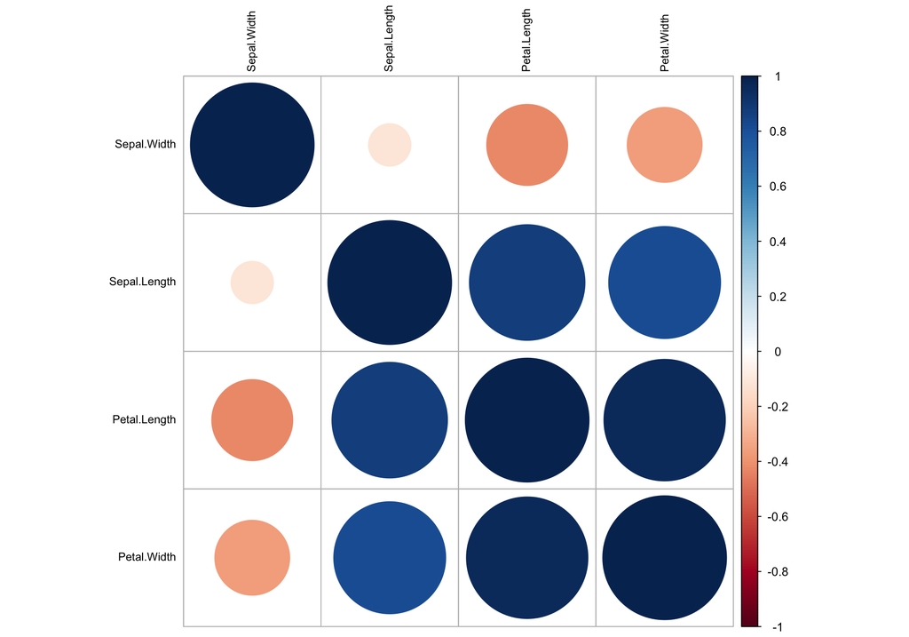

```r
iris %>%
  select(-Species) %>%
      cor() %>%
  corrplot(order = "hclust", tl.col = 'black', tl.cex = .75)
```

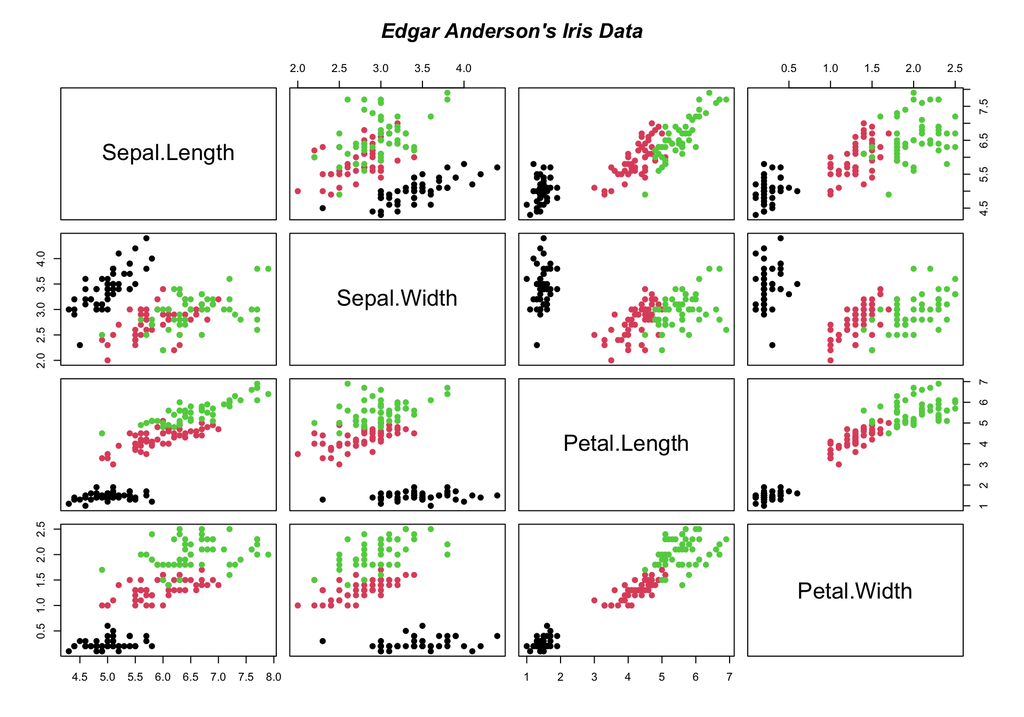

```r
iris %>%
  select(-Species) %>%
  pairs(main = "Edgar Anderson's Iris Data", font.main = 4, pch = 19, col = iris$Species)
```

```r
df_iris <- iris %>%
  select(-Species)

df_iris %>%
  cor() %>%
  knitr::kable(caption = "Таблиця оцінок коефіцієнтів кореляції")
```

Таблиця оцінок коефіцієнтів кореляції

|  | Sepal.Length | Sepal.Width | Petal.Length | Petal.Width |
| --- | --- | --- | --- | --- |
| Sepal.Length | 1.0000000 | -0.1175698 | 0.8717538 | 0.8179411 |
| Sepal.Width | -0.1175698 | 1.0000000 | -0.4284401 | -0.3661259 |
| Petal.Length | 0.8717538 | -0.4284401 | 1.0000000 | 0.9628654 |
| Petal.Width | 0.8179411 | -0.3661259 | 0.9628654 | 1.0000000 |

Що ми бачимо?

- має місце сильний позитивний кореляційний зв’язок між змінною `Sepal.Length` та змінними `Petal.Length`, `Petal.Width`; на кореляційних полях чітко видно наявність даної кореляції
- на кореляційних полях чітко видно наявність неоднородності даних – дані чітко поділяються на гомогенні групи за змінною `Species`
- має місце слабкий від’ємний кореляційний зв’язок `Petal.Length` і `Sepal.Width`; дана кореляція є уявною в силу сегментованості даних по змінній `Species`: якщо уважно дослідити форму кореляційних полів для кожного значення данної змінної, то можна побачити, що всередині кожного сегменту має місце позитивна кореляція

Що це нам дає?

- наявність високого ступеня кореляції дає можливість знизити розмірність даних і знайти просту структуру у просторі меншої розмірності
- у просторі меншої розмірності можна можна виконати сегментацію даних.

Для зниження розмірності і одночасно сегментації даних скористаємося методом головних компонент (PCA).

```r
#PCA
resPCA <- iris %>%
  select(-Species) %>%
  PCA(ncp = 8, graph = FALSE)
```

```r
eigenvalues <- as.data.frame(resPCA$eig)
cumVar <- round(eigenvalues$`cumulative percentage of variance`[length(eigenvalues$eigenvalue[eigenvalues$eigenvalue >= 0.9])], 2)
```

```r
knitr::kable(
  eigenvalues,
  caption = "Власні значення (eigenvalues) і сумарний процент поясненої дисперсії"
)
```

Власні значення (eigenvalues) і сумарний процент поясненої дисперсії

|  | eigenvalue | percentage of variance | cumulative percentage of variance |
| --- | --- | --- | --- |
| comp 1 | 2.9184978 | 72.9624454 | 72.96245 |
| comp 2 | 0.9140305 | 22.8507618 | 95.81321 |
| comp 3 | 0.1467569 | 3.6689219 | 99.48213 |
| comp 4 | 0.0207148 | 0.5178709 | 100.00000 |

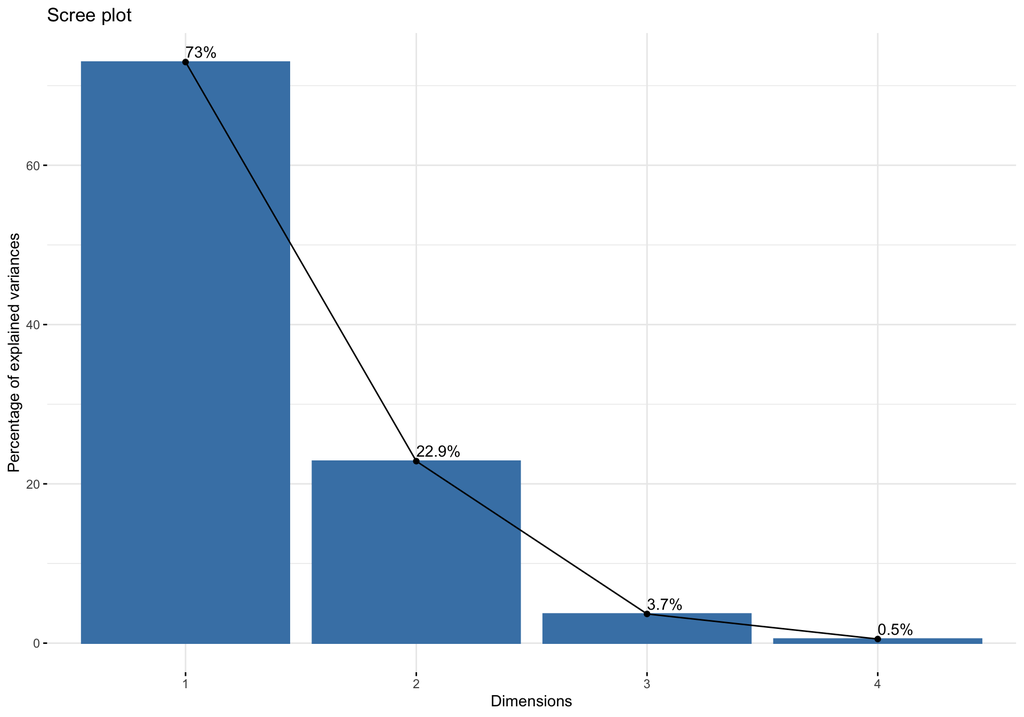

```r
fviz_screeplot(resPCA, addlabels = TRUE,  ncp=10)
```

Чщо ми бачимо?  
Ми маємо *p*= 2 головних компонент, які пояснюють 95.81 % дисперсії. Це значить, що м маємо всього дві нові компоненти замість чотирьох і практично без втрати інформації можемо представити всі спостереження в системі двох координат на площині: перша компонента по осі `Х`, друга – по осі Y (див. рис.).  
Проаналізуємо детально структуру двох перших компонент, виключивши решту незначимих (див. табл. і рис.).

```r
knitr::kable(
  resPCA$var$coord[ ,1:2],
  caption = "Таблиця навантажень"
)
```

Таблиця навантажень

|  | Dim.1 | Dim.2 |
| --- | --- | --- |
| Sepal.Length | 0.8901688 | 0.3608299 |
| Sepal.Width | -0.4601427 | 0.8827163 |
| Petal.Length | 0.9915552 | 0.0234152 |
| Petal.Width | 0.9649790 | 0.0639998 |

Що ми бачимо?

- Структуру першої компоненти головним чином складають три початкові змінні: `Sepal.Length`, `Petal.Length`, `Petal.Width`; як і прогнозувалося раніше, саме за цією компонентою відбувається дискримінація (розрізнення) трьох різних сегментів трьох типів ірисів
- основне навантаження на другу компоненту складає змінна `Sepal.Width` – всі три види ірисів можуть мати досить велику варіацію за цим параметром.

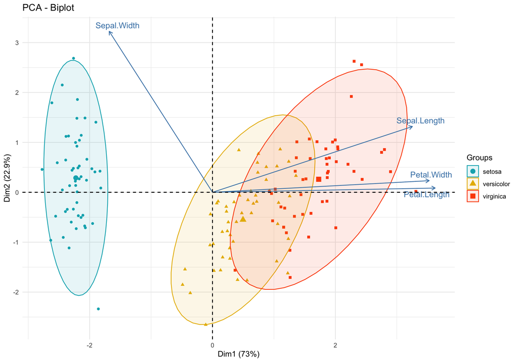

```r
# Biplot of individuals and variables
fviz_pca_biplot(resPCA,
                geom = c("point"),
                # label = "none", # hide individual labels
             habillage = as.factor(iris$Species), # color by groups
             axes = c(1, 2),
             repel = TRUE,
             label = c("ind", "ind.sup", "quali", "var", "quanti.sup"),
             select.var = list(name = c("Sepal.Length", "Sepal.Width", "Petal.Length", "Petal.Width")),
             # select.var = list(contrib = 8),
             # label = c("ind.sup"),
             palette = c("#00AFBB", "#E7B800", "#FC4E07", "#00AFBB", "#E7B800", "#FC4E07"),
             # alpha.var = c("contrib"),
             # col.ind = c("contrib"),
             # col.ind.sup = c("contrib"),
             addEllipses = TRUE # Concentration ellipses
             ) +
  theme_minimal()
```

Таким чином, з’ясовано, шо початкові дані не є однорідними. Три типи ірисів різняться за довжинами внутрішніх часток оцвітини (petal length) та шириною внутрішньої частки оцвітини (petal width). Завдяки наявності кореляцій у початкових змінних, спостереження вдалося добре описати у просторі двох інтегральних показників. Знайдені кластери характерні для трьох типів ірисів і у майбутньому можуть бути використані для написання класифікатора з метою розпізнавання нових об’єктів.

## References

Casas, Pablo. 2020. funModeling: Exploratory Data Analysis and Data Preparation Tool-Box. https://livebook.datascienceheroes.com.

Garrett Grolemund, Hadley Wickham. 2018. R for Data Science. http://r4ds.had.co.nz/index.html.

Science, Eberly College of. 2020. “STAT 505: Applied Multivariate Statistical Analysis.” Course materials. http://belousovv.ru/markdown_syntax#fnref:2. wikipedia. 2018a. “Cross-Industry Standard Process for Data Mining.” Article. https://en.wikipedia.org/wiki/Cross-industry_standard_process_for_data_mining.

2018b. “Exploratory Data Analysis.” Article. https://en.wikipedia.org/wiki/Exploratory_data_analysis.

2018c. “Principal Component Analysis.” Article. https://en.wikipedia.org/wiki/Principal_component_analysis.

wikipedia. 2018. “Principal Component Analysis.” Article. https://en.wikipedia.org/wiki/Principal_component_analysis.